# weather

seok

2018년 6월 9일

# 1 추론 통계 분석

- 모집단에서 추출한 표본의 정보를 이용하여 모집단의 특성을 추론하는 추론 통계학

## 1.1 날씨 데이터의 상관관계 분석

- 변수들의 상관성을 바탕으로 변수를 정제하는 상관관계 분석

[output not shown]

### 1.1.1 데이터 호출

- 날씨 관련 변수에 따라서 비가 내릴지의 여부를 기록한 데이터
- 이 데이터를 분석하여 어떤 날씨 조건에 비가 내릴지 또는 내리지 않을지에 대한 판단 기준을 분석할 수 있다.
- Date(측정날짜), MinTemp(최저기온), MaxTemp(최고기온), Rainfall(강수량), Sunshine(햇빛)
- WindGustDir(돌풍방향), WidGustSpeed(돌풍 속도), WindDir(바람 방향), WindSpeed(바람 속도)
- Humidity(습도), Pressure(기압), Cloud(구름), Temp(온도), RainToday(금일 비 여부), RainTomorrow(내일 비 여부)

```r
weather = read.csv("../data/weather.csv", stringsAsFactors = F)
# 데이터 확인
weather
```

```
##           Date MinTemp MaxTemp Rainfall Sunshine WindGustDir WindGustSpeed
## 1   2014-11-01     8.0    24.3      0.0      6.3          NW            30
## 2   2014-11-02    14.0    26.9      3.6      9.7         ENE            39
## 3   2014-11-03    13.7    23.4      3.6      3.3          NW            85
## 4   2014-11-04    13.3    15.5     39.8      9.1          NW            54
## 5   2014-11-05     7.6    16.1      2.8     10.6         SSE            50
## 6   2014-11-06     6.2    16.9      0.0      8.2          SE            44
## 7   2014-11-07     6.1    18.2      0.2      8.4          SE            43
## 8   2014-11-08     8.3    17.0      0.0      4.6           E            41
## 9   2014-11-09     8.8    19.5      0.0      4.1           S            48
## 10  2014-11-10     8.4    22.8     16.2      7.7           E            31
## 11  2014-11-11     9.1    25.2      0.0     11.9           N            30
## 12  2014-11-12     8.5    27.3      0.2     12.5           E            41
## 13  2014-11-13    10.1    27.9      0.0     13.0         WNW            30
## 14  2014-11-14    12.1    30.9      0.0     12.4          NW            44
```

[output cut: 719 more lines]

### 1.1.2 데이터 확인 방법

```r
length(weather$Date) # 데이터 객체의 요소들의 개수
```

```
## [1] 366
```

```r
names(weather) # 데이터 객체 구성요소 이름
```

```
##  [1] "Date"          "MinTemp"       "MaxTemp"       "Rainfall"
##  [5] "Sunshine"      "WindGustDir"   "WindGustSpeed" "WindDir"
##  [9] "WindSpeed"     "Humidity"      "Pressure"      "Cloud"
## [13] "Temp"          "RainToday"     "RainTomorrow"
```

```r
class(weather) # 데이터 객체 구성요소의 속성
```

```
## [1] "data.frame"
```

```r
attributes(weather) # 변수 속성 보기
```

```
## $names
##  [1] "Date"          "MinTemp"       "MaxTemp"       "Rainfall"
##  [5] "Sunshine"      "WindGustDir"   "WindGustSpeed" "WindDir"
##  [9] "WindSpeed"     "Humidity"      "Pressure"      "Cloud"
## [13] "Temp"          "RainToday"     "RainTomorrow"
##
## $class
## [1] "data.frame"
##
## $row.names
##   [1]   1   2   3   4   5   6   7   8   9  10  11  12  13  14  15  16  17
##  [18]  18  19  20  21  22  23  24  25  26  27  28  29  30  31  32  33  34
##  [35]  35  36  37  38  39  40  41  42  43  44  45  46  47  48  49  50  51
##  [52]  52  53  54  55  56  57  58  59  60  61  62  63  64  65  66  67  68
##  [69]  69  70  71  72  73  74  75  76  77  78  79  80  81  82  83  84  85
```

[output cut: 17 more lines]

```r
summary(weather) # 데이터 요약 보기
```

```
##      Date              MinTemp          MaxTemp         Rainfall
##  Length:366         Min.   :-5.300   Min.   : 7.60   Min.   : 0.000
##  Class :character   1st Qu.: 2.300   1st Qu.:15.03   1st Qu.: 0.000
##  Mode  :character   Median : 7.450   Median :19.65   Median : 0.000
##                     Mean   : 7.266   Mean   :20.55   Mean   : 1.428
##                     3rd Qu.:12.500   3rd Qu.:25.50   3rd Qu.: 0.200
##                     Max.   :20.900   Max.   :35.80   Max.   :39.800
##
##     Sunshine      WindGustDir        WindGustSpeed     WindDir
##  Min.   : 0.000   Length:366         Min.   :13.00   Length:366
##  1st Qu.: 5.950   Class :character   1st Qu.:31.00   Class :character
##  Median : 8.600   Mode  :character   Median :39.00   Mode  :character
##  Mean   : 7.909                      Mean   :39.84
##  3rd Qu.:10.500                      3rd Qu.:46.00
##  Max.   :13.600                      Max.   :98.00
##  NA's   :3                           NA's   :2
##    WindSpeed        Humidity        Pressure          Cloud
##  Min.   : 0.00   Min.   :13.00   Min.   : 996.8   Min.   :0.000
##  1st Qu.:11.00   1st Qu.:32.25   1st Qu.:1012.8   1st Qu.:1.000
##  Median :17.00   Median :43.00   Median :1017.4   Median :4.000
##  Mean   :17.99   Mean   :44.52   Mean   :1016.8   Mean   :4.025
##  3rd Qu.:24.00   3rd Qu.:55.00   3rd Qu.:1021.5   3rd Qu.:7.000
##  Max.   :52.00   Max.   :96.00   Max.   :1033.2   Max.   :8.000
##
##       Temp        RainToday         RainTomorrow
##  Min.   : 5.10   Length:366         Length:366
##  1st Qu.:14.15   Class :character   Class :character
##  Median :18.55   Mode  :character   Mode  :character
##  Mean   :19.23
##  3rd Qu.:24.00
##  Max.   :34.50
##
```

```r
dim(weather) # 데이터 객체의 차원보기
```

```
## [1] 366  15
```

```r
head(weather) # 상위 6개 관측치 미리보기
```

```
##         Date MinTemp MaxTemp Rainfall Sunshine WindGustDir WindGustSpeed
## 1 2014-11-01     8.0    24.3      0.0      6.3          NW            30
## 2 2014-11-02    14.0    26.9      3.6      9.7         ENE            39
## 3 2014-11-03    13.7    23.4      3.6      3.3          NW            85
## 4 2014-11-04    13.3    15.5     39.8      9.1          NW            54
## 5 2014-11-05     7.6    16.1      2.8     10.6         SSE            50
## 6 2014-11-06     6.2    16.9      0.0      8.2          SE            44
##   WindDir WindSpeed Humidity Pressure Cloud Temp RainToday RainTomorrow
## 1      NW        20       29   1015.0     7 23.6        No          Yes
## 2       W        17       36   1008.4     3 25.7       Yes          Yes
## 3     NNE         6       69   1007.2     7 20.2       Yes          Yes
## 4       W        24       56   1007.0     7 14.1       Yes          Yes
## 5     ESE        28       49   1018.5     7 15.4       Yes           No
## 6       E        24       57   1021.7     5 14.8        No           No
```

```r
tail(weather) # 하위 6개 관측치 미리보기
```

```
##           Date MinTemp MaxTemp Rainfall Sunshine WindGustDir WindGustSpeed
## 361 2015-10-27     7.9    26.1        0      3.5         NNW            43
## 362 2015-10-28     9.0    30.7        0     12.1         NNW            76
## 363 2015-10-29     7.1    28.4        0     12.7           N            48
## 364 2015-10-30    12.5    19.9        0      5.3         ESE            43
## 365 2015-10-31    12.5    26.9        0      7.1          NW            46
## 366 2015-11-01    12.3    30.2        0     12.6          NW            78
##     WindDir WindSpeed Humidity Pressure Cloud Temp RainToday RainTomorrow
## 361     WNW        19       20   1014.2     8 25.9        No           No
## 362      NW        50       15   1010.8     3 30.0        No           No
## 363     NNW        19       22   1016.9     1 28.2        No           No
## 364     ENE         9       47   1022.8     2 18.3        No           No
## 365     WNW        28       39   1016.2     7 25.9        No           No
## 366     WNW        35       13   1009.2     1 28.6        No           No
```

```r
str(weather) # 데이터 구조, 변수 개수, 변수 명, 관찰치 개수, 관찰치의 미리보기
```

```
## 'data.frame':    366 obs. of  15 variables:
##  $ Date         : chr  "2014-11-01" "2014-11-02" "2014-11-03" "2014-11-04" ...
##  $ MinTemp      : num  8 14 13.7 13.3 7.6 6.2 6.1 8.3 8.8 8.4 ...
##  $ MaxTemp      : num  24.3 26.9 23.4 15.5 16.1 16.9 18.2 17 19.5 22.8 ...
##  $ Rainfall     : num  0 3.6 3.6 39.8 2.8 0 0.2 0 0 16.2 ...
##  $ Sunshine     : num  6.3 9.7 3.3 9.1 10.6 8.2 8.4 4.6 4.1 7.7 ...
##  $ WindGustDir  : chr  "NW" "ENE" "NW" "NW" ...
##  $ WindGustSpeed: int  30 39 85 54 50 44 43 41 48 31 ...
##  $ WindDir      : chr  "NW" "W" "NNE" "W" ...
##  $ WindSpeed    : int  20 17 6 24 28 24 26 24 17 6 ...
##  $ Humidity     : int  29 36 69 56 49 57 47 57 48 32 ...
##  $ Pressure     : num  1015 1008 1007 1007 1018 ...
##  $ Cloud        : int  7 3 7 7 7 5 6 7 7 1 ...
##  $ Temp         : num  23.6 25.7 20.2 14.1 15.4 14.8 17.3 15.5 18.9 21.7 ...
##  $ RainToday    : chr  "No" "Yes" "Yes" "Yes" ...
##  $ RainTomorrow : chr  "Yes" "Yes" "Yes" "Yes" ...
```

### 1.1.3 데이터 전처리

```r
weather_num <- weather[, c(-1, -6, -8, -14, -15)]
str(weather_num)
```

```
## 'data.frame':    366 obs. of  10 variables:
##  $ MinTemp      : num  8 14 13.7 13.3 7.6 6.2 6.1 8.3 8.8 8.4 ...
##  $ MaxTemp      : num  24.3 26.9 23.4 15.5 16.1 16.9 18.2 17 19.5 22.8 ...
##  $ Rainfall     : num  0 3.6 3.6 39.8 2.8 0 0.2 0 0 16.2 ...
##  $ Sunshine     : num  6.3 9.7 3.3 9.1 10.6 8.2 8.4 4.6 4.1 7.7 ...
##  $ WindGustSpeed: int  30 39 85 54 50 44 43 41 48 31 ...
##  $ WindSpeed    : int  20 17 6 24 28 24 26 24 17 6 ...
##  $ Humidity     : int  29 36 69 56 49 57 47 57 48 32 ...
##  $ Pressure     : num  1015 1008 1007 1007 1018 ...
##  $ Cloud        : int  7 3 7 7 7 5 6 7 7 1 ...
##  $ Temp         : num  23.6 25.7 20.2 14.1 15.4 14.8 17.3 15.5 18.9 21.7 ...
```

```r
# 결측치 확인
colSums(is.na(weather_num))
```

```
##       MinTemp       MaxTemp      Rainfall      Sunshine WindGustSpeed
##             0             0             0             3             2
##     WindSpeed      Humidity      Pressure         Cloud          Temp
##             0             0             0             0             0
```

### 1.1.4 상관계수 확인

```r
# cor(weather) # numeric 데이터만 가능
cor(weather_num, method = "pearson") # 상관관계 확인
```

```
##                   MinTemp     MaxTemp    Rainfall Sunshine WindGustSpeed
## MinTemp        1.00000000  0.75247079  0.20193872       NA            NA
## MaxTemp        0.75247079  1.00000000 -0.07355958       NA            NA
## Rainfall       0.20193872 -0.07355958  1.00000000       NA            NA
## Sunshine               NA          NA          NA        1            NA
## WindGustSpeed          NA          NA          NA       NA             1
## WindSpeed     -0.06592182 -0.16787312  0.05600849       NA            NA
## Humidity      -0.04070877 -0.53332688  0.28901341       NA            NA
## Pressure      -0.49800692 -0.37939373 -0.25021761       NA            NA
## Cloud          0.11839736 -0.13599065  0.12779204       NA            NA
## Temp           0.72273050  0.98926079 -0.08749319       NA            NA
##                 WindSpeed    Humidity    Pressure       Cloud        Temp
## MinTemp       -0.06592182 -0.04070877 -0.49800692  0.11839736  0.72273050
## MaxTemp       -0.16787312 -0.53332688 -0.37939373 -0.13599065  0.98926079
## Rainfall       0.05600849  0.28901341 -0.25021761  0.12779204 -0.08749319
## Sunshine               NA          NA          NA          NA          NA
## WindGustSpeed          NA          NA          NA          NA          NA
## WindSpeed      1.00000000 -0.02636775 -0.33732535  0.00720724 -0.18756965
## Humidity      -0.02636775  1.00000000 -0.01005189  0.51010790 -0.58167615
## Pressure      -0.33732535 -0.01005189  1.00000000 -0.14383718 -0.34548531
## Cloud          0.00720724  0.51010790 -0.14383718  1.00000000 -0.17281423
## Temp          -0.18756965 -0.58167615 -0.34548531 -0.17281423  1.00000000
```

### 1.1.5 데이터 전처리 2

```r
weather_num2 <- na.omit(weather_num) # 결측치를 포함한 행 제거

colSums(is.na(weather_num2)) # 결측치 제거 확인
```

```
##       MinTemp       MaxTemp      Rainfall      Sunshine WindGustSpeed
##             0             0             0             0             0
##     WindSpeed      Humidity      Pressure         Cloud          Temp
##             0             0             0             0             0
```

### 1.1.6 상관계수 확인

```r
cor(weather_num2, method = "pearson")
```

```
##                   MinTemp    MaxTemp    Rainfall    Sunshine WindGustSpeed
## MinTemp        1.00000000  0.7528417  0.19629243  0.03712155    0.21563742
## MaxTemp        0.75284166  1.0000000 -0.07818860  0.45408861    0.10694128
## Rainfall       0.19629243 -0.0781886  1.00000000 -0.15068501    0.09532589
## Sunshine       0.03712155  0.4540886 -0.15068501  1.00000000    0.09584272
## WindGustSpeed  0.21563742  0.1069413  0.09532589  0.09584272    1.00000000
## WindSpeed     -0.07057462 -0.1687830  0.05117158  0.07254811    0.69470706
## Humidity      -0.04856916 -0.5383779  0.28666809 -0.75979510   -0.07029527
## Pressure      -0.49520944 -0.3770701 -0.25125627 -0.03740636   -0.52478951
## Cloud          0.10821155 -0.1432029  0.13105977 -0.66232664    0.05052383
## Temp           0.72354652  0.9892214 -0.09172749  0.47233003    0.06968778
##                  WindSpeed    Humidity    Pressure        Cloud
## MinTemp       -0.070574620 -0.04856916 -0.49520944  0.108211552
## MaxTemp       -0.168782971 -0.53837794 -0.37707008 -0.143202950
## Rainfall       0.051171576  0.28666809 -0.25125627  0.131059766
## Sunshine       0.072548114 -0.75979510 -0.03740636 -0.662326636
## WindGustSpeed  0.694707060 -0.07029527 -0.52478951  0.050523835
## WindSpeed      1.000000000 -0.03101386 -0.33839811  0.006244681
## Humidity      -0.031013858  1.00000000 -0.01170095  0.511175462
## Pressure      -0.338398109 -0.01170095  1.00000000 -0.141730139
## Cloud          0.006244681  0.51117546 -0.14173014  1.000000000
## Temp          -0.188218230 -0.58636265 -0.34304952 -0.179481518
##                      Temp
## MinTemp        0.72354652
## MaxTemp        0.98922136
## Rainfall      -0.09172749
## Sunshine       0.47233003
## WindGustSpeed  0.06968778
## WindSpeed     -0.18821823
## Humidity      -0.58636265
## Pressure      -0.34304952
## Cloud         -0.17948152
## Temp           1.00000000
```

### 1.1.7 Pairs() 함수를 이용하여 산점도 행렬을 그리기 위해 사용자 정의함수 사용

```r
# help("pairs")에서 참고한 함수들
# 산점도 행렬의 대각선에 히스토그램을 추가하는 사용자 정의 함수
panel.hist <- function(x, ...)
{
  usr <- par("usr"); on.exit(par(usr))
  par(usr = c(usr[1:2], 0, 1.5) )
  h <- hist(x, plot = FALSE)
  breaks <- h$breaks; nB <- length(breaks)
  y <- h$counts; y <- y/max(y)
  rect(breaks[-nB], 0, breaks[-1], y, col = "cyan", ...)
}

# 다음으로 산점도 행렬의 위쪽에 상관계수 숫자를 집어넣는 사용자 정의 함수
panel.cor <- function(x, y, digits = 2, prefix = "", cex.cor, ...)
{
  usr <- par("usr"); on.exit(par(usr))
  par(usr = c(0, 1, 0, 1))
  r <- abs(cor(x, y))
  txt <- format(c(r, 0.123456789), digits = digits)[1]
  txt <- paste0(prefix, txt)
  if(missing(cex.cor)) cex.cor <- 0.8/strwidth(txt)
  text(0.5, 0.5, txt, cex = cex.cor * r)
}

# 산점도에 선형 회귀선을 추가하는 사용자 정의 함수
panel.lm <- function(x, y, col=par("col"), bg=NA, pch=par("pch"),
                     cex=1, col.smooth="black", ...) {
  points(x, y, pch=pch, col=col, bg=bg, cex=cex)
  abline(stats::lm(y~x), col=col.smooth, ...)
}
```

### 1.1.8 산점도 행렬(scatter-plot matrix), 상관계수(correlation), 히스토그램(histogram)

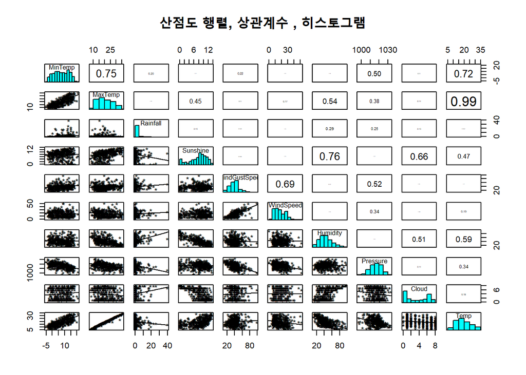

```r
pairs(
  weather_num2,
  lower.panel = panel.lm,
  upper.panel = panel.cor,
  diag.panel = panel.hist,
  pch="*",
  main = "산점도 행렬, 상관계수 , 히스토그램"
)
```

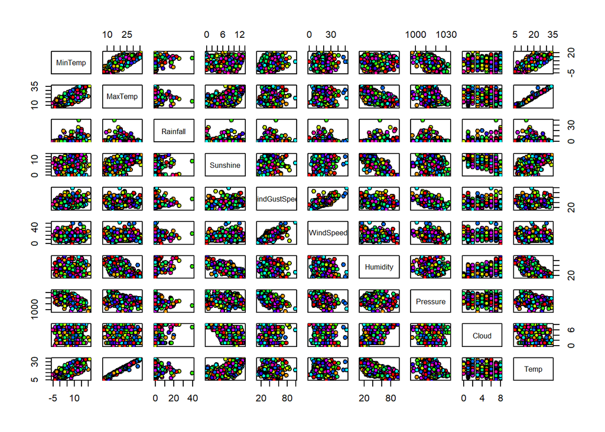

```r
pairs(
  weather_num2,
  pch=21,
  bg=rainbow(10)
)
```

### 1.1.9 데이터 전처리 3

```r
# 관련이 있는 데이터만 다시 전처리
weather_num3 <- weather_num2[, c(-3)]
```

### 1.1.10 산점도 행렬(scatter-plot matrix), 상관계수(correlation), 히스토그램(histogram) 2

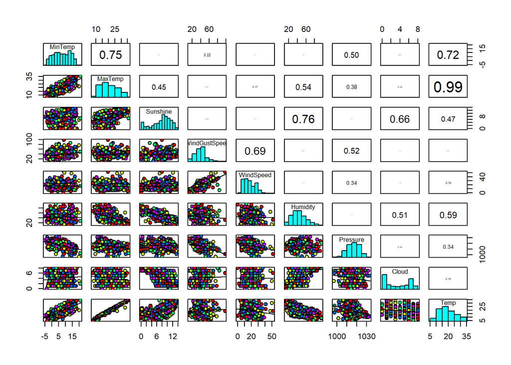

```r
# cor(weather_num3, method="pearson") # 대상변수가 등간척도 또는 비율척도 일 때 pearson 상관계수를 적용
# cor(weather_num3, method="spearman") # 서열척도일 때는 spearman 상관계수를 적용
pairs(
  weather_num3,
  lower.panel = panel.lm,
  upper.panel = panel.cor,
  diag.panel = panel.hist,
  pch=21,
  bg=rainbow(5)
)
```

# 2 예측 분석

- 추론 통계 및 패턴(규칙)을 적용하여 미래의 데이터를 예측하는 분석방법

## 2.1 로지스틱 회귀분석

- 종속변수와 독립변수 간의 관계를 나타내어 예측 모델을 생성한다는 점에서 선형회귀분석과 동일
- 독립변수(x)에 의해서 종속변수(y)의 범주로 분류한다는 측면은 분류분석 방법으로 분류된다.

### 2.1.1 로지스틱 회귀분석의 특징

- 분석 목적 : 종속변수와 독립변수 간의 관계를 통해서 예측 모델을 생성하는 데 있다.
- 단순 회귀분석과 차이점: 종속변수는 반드시 범주형 변수이어야 한다.
- 정규성: 정규분대신에 이항분포를 따른다.
- 로짓 변환 : 종속변수의 출력범위를 0과 1로 조정하는 과정을 의미
- 활용 분야 : 의료, 통신, 날씨 등 다양한 분야에서 활용

### 2.1.2 데이터 확인

```r
str(weather) # 데이터 구조, 변수 개수, 변수 명, 관찰치 개수, 관찰치의 미리보기
```

```
## 'data.frame':    366 obs. of  15 variables:
##  $ Date         : chr  "2014-11-01" "2014-11-02" "2014-11-03" "2014-11-04" ...
##  $ MinTemp      : num  8 14 13.7 13.3 7.6 6.2 6.1 8.3 8.8 8.4 ...
##  $ MaxTemp      : num  24.3 26.9 23.4 15.5 16.1 16.9 18.2 17 19.5 22.8 ...
##  $ Rainfall     : num  0 3.6 3.6 39.8 2.8 0 0.2 0 0 16.2 ...
##  $ Sunshine     : num  6.3 9.7 3.3 9.1 10.6 8.2 8.4 4.6 4.1 7.7 ...
##  $ WindGustDir  : chr  "NW" "ENE" "NW" "NW" ...
##  $ WindGustSpeed: int  30 39 85 54 50 44 43 41 48 31 ...
##  $ WindDir      : chr  "NW" "W" "NNE" "W" ...
##  $ WindSpeed    : int  20 17 6 24 28 24 26 24 17 6 ...
##  $ Humidity     : int  29 36 69 56 49 57 47 57 48 32 ...
##  $ Pressure     : num  1015 1008 1007 1007 1018 ...
##  $ Cloud        : int  7 3 7 7 7 5 6 7 7 1 ...
##  $ Temp         : num  23.6 25.7 20.2 14.1 15.4 14.8 17.3 15.5 18.9 21.7 ...
##  $ RainToday    : chr  "No" "Yes" "Yes" "Yes" ...
##  $ RainTomorrow : chr  "Yes" "Yes" "Yes" "Yes" ...
```

### 2.1.3 데이터 전처리

#### 2.1.3.1 결측치 확인

```r
# sum(is.na(weather)) # 전체 결측치 갯수 확인
# sum(is.na(weather$Sunshine)) # Sunshine 컬럼의 결측치 갯수 확인
# sum(is.na(weather$WindGustDir)) # WindGustDir 컬럼의 결측치 갯수 확인
# sum(is.na(weather$WindGustSpeed)) # WindGustSpeed 컬럼의 결측치 갯수 확인
# sum(is.na(weather$WindDir)) # WindDir 컬럼의 결측치 갯수 확인

colSums(is.na(weather)) # 한번에 결측값 현황 파악하는 방법
```

```
##          Date       MinTemp       MaxTemp      Rainfall      Sunshine
##             0             0             0             0             3
##   WindGustDir WindGustSpeed       WindDir     WindSpeed      Humidity
##             3             2             1             0             0
##      Pressure         Cloud          Temp     RainToday  RainTomorrow
##             0             0             0             0             0
```

#### 2.1.3.2 데이터 변환

```r
weather_df <- weather[, c(-1, -6, -8, -14)] # chr 데이터 타입 컬럼, Date, RainToday 컬럼 제거
str(weather_df) # 컬럼 삭제 후 확인
```

```
## 'data.frame':    366 obs. of  11 variables:
##  $ MinTemp      : num  8 14 13.7 13.3 7.6 6.2 6.1 8.3 8.8 8.4 ...
##  $ MaxTemp      : num  24.3 26.9 23.4 15.5 16.1 16.9 18.2 17 19.5 22.8 ...
##  $ Rainfall     : num  0 3.6 3.6 39.8 2.8 0 0.2 0 0 16.2 ...
##  $ Sunshine     : num  6.3 9.7 3.3 9.1 10.6 8.2 8.4 4.6 4.1 7.7 ...
##  $ WindGustSpeed: int  30 39 85 54 50 44 43 41 48 31 ...
##  $ WindSpeed    : int  20 17 6 24 28 24 26 24 17 6 ...
##  $ Humidity     : int  29 36 69 56 49 57 47 57 48 32 ...
##  $ Pressure     : num  1015 1008 1007 1007 1018 ...
##  $ Cloud        : int  7 3 7 7 7 5 6 7 7 1 ...
##  $ Temp         : num  23.6 25.7 20.2 14.1 15.4 14.8 17.3 15.5 18.9 21.7 ...
##  $ RainTomorrow : chr  "Yes" "Yes" "Yes" "Yes" ...
```

```r
weather_df$RainTomorrow[weather_df$RainTomorrow=="Yes"] <- 1 # Yes -> 1
weather_df$RainTomorrow[weather_df$RainTomorrow=="No"] <- 0 # Tes -> 0
weather_df$RainTomorrow <- as.numeric(weather_df$RainTomorrow) # 수정한 값을 numeric으로 형변환
```

#### 2.1.3.3 데이터 확인

```r
head(weather_df)
```

```
##   MinTemp MaxTemp Rainfall Sunshine WindGustSpeed WindSpeed Humidity
## 1     8.0    24.3      0.0      6.3            30        20       29
## 2    14.0    26.9      3.6      9.7            39        17       36
## 3    13.7    23.4      3.6      3.3            85         6       69
## 4    13.3    15.5     39.8      9.1            54        24       56
## 5     7.6    16.1      2.8     10.6            50        28       49
## 6     6.2    16.9      0.0      8.2            44        24       57
##   Pressure Cloud Temp RainTomorrow
## 1   1015.0     7 23.6            1
## 2   1008.4     3 25.7            1
## 3   1007.2     7 20.2            1
## 4   1007.0     7 14.1            1
## 5   1018.5     7 15.4            0
## 6   1021.7     5 14.8            0
```

### 2.1.4 학습 데이터와 검정 데이터 생성 (7:3 비율)

```r
# 단순 임의 추출
idx <- sample(1:nrow(weather_df), nrow(weather_df) * 0.7) # 70%의 데이터만을 training 데이터로  사
train <- weather_df[idx, ]
# train <- na.omit(train)
test <- weather_df[-idx, ]
# colSums(is.na(train))
```

### 2.1.5 로지스틱 회귀모델 생성

```r
# generalized linear model
# glm(y ~ x, data, family)
# family의 'binomial'은 y 변수가 이항형인 경우 지정하는 속성 값
weather_model <- glm(RainTomorrow ~ ., data=train, family="binomial")
# weather_model
summary(weather_model)
```

```
##
## Call:
## glm(formula = RainTomorrow ~ ., family = "binomial", data = train)
##
## Deviance Residuals:
##     Min       1Q   Median       3Q      Max
## -1.9778  -0.4104  -0.2377  -0.1159   2.5506
##
## Coefficients:
##                Estimate Std. Error z value Pr(>|z|)
## (Intercept)   114.25407   47.04648   2.429  0.01516 *
## MinTemp        -0.03327    0.08344  -0.399  0.69004
## MaxTemp         0.09486    0.24714   0.384  0.70110
## Rainfall       -0.00701    0.04652  -0.151  0.88022
## Sunshine       -0.24363    0.11034  -2.208  0.02724 *
## WindGustSpeed   0.07092    0.02718   2.609  0.00908 **
## WindSpeed      -0.05203    0.03590  -1.450  0.14717
## Humidity        0.04411    0.02910   1.516  0.12957
## Pressure       -0.12007    0.04539  -2.645  0.00816 **
## Cloud           0.15245    0.12346   1.235  0.21688
## Temp            0.05501    0.25933   0.212  0.83201
## ---
## Signif. codes:  0 '***' 0.001 '**' 0.01 '*' 0.05 '.' 0.1 ' ' 1
##
## (Dispersion parameter for binomial family taken to be 1)
##
##     Null deviance: 223.48  on 250  degrees of freedom
## Residual deviance: 135.47  on 240  degrees of freedom
##   (5 observations deleted due to missingness)
## AIC: 157.47
##
## Number of Fisher Scoring iterations: 6
```

### 2.1.6 로지스틱 회귀모델 예측치 생성

```r
# newdata=test : 새로운 데이터 셋, type="response" : 0~1 확률값으로 예측
pred <- predict(weather_model, newdata=test, type="response")
pred # 1에 가까울 수록 비올 확률이 높다.
```

```
##           8          13          16          17          20          26
## 0.082115121 0.017274689 0.180177640 0.301677803 0.070515284 0.112748564
##          31          32          38          39          41          46
## 0.841413738 0.162171299 0.155714814 0.147765326 0.307673241 0.911056878
##          55          61          63          64          65          66
## 0.171589945 0.023007921 0.179803984 0.598131096 0.090903154 0.108643927
##          67          72          75          76          77          80
## 0.304035101 0.297083988 0.512341304 0.103100520 0.899911646 0.921963895
##          82          84          85          86          88          93
## 0.646011883 0.026284127 0.071935995 0.112707219 0.140555257 0.164192722
##          95          99         100         102         107         121
## 0.379266690 0.971043121 0.525270786 0.178225296 0.020997980 0.018537022
##         127         134         139         143         146         147
## 0.063308913 0.074958433 0.042379658 0.295676982 0.943548288 0.155731749
##         151         154         156         157         159         164
## 0.039986232 0.760835491 0.007410535 0.005471428 0.034042100 0.115611073
##         165         166         171         180         181         185
## 0.128889500 0.007449905 0.027582548 0.417665049 0.004621378 0.015178765
##         187         189         194         197         203         205
## 0.070338936 0.020049819 0.011652736 0.015860685 0.014891827 0.006316835
##         206         211         213         214         216         223
## 0.003128058 0.003290890 0.005710666 0.047054532 0.191320641 0.607736668
##         226         228         232         233         235         237
## 0.079176540 0.012455864 0.142718991 0.410047853 0.011477871 0.078542387
##         238         243         245         256         258         259
## 0.009702368 0.755303342 0.072965528 0.179220076 0.038360628 0.088690383
##         261         267         268         269         273         275
## 0.202764501 0.007349650 0.003863110 0.061200940 0.016003944 0.951657123
##         278         279         282         288         290         291
## 0.058978945 0.256617314 0.025571361 0.010642118 0.010407592 0.001805273
##         295         296         304         305         306         307
## 0.091364840 0.096289075 0.292735732 0.934845365 0.003706873 0.006565586
##         309         311         316         320         326         327
## 0.048061538 0.073698075 0.005760850 0.778081600 0.006950789 0.965108811
##         330         341         345         351         353         357
## 0.002467565 0.267586729 0.006375774 0.003789188 0.062359355 0.011094684
##         363         366
## 0.032521701 0.178580148
```

```r
# summary(pred)
# str(pred)
# 예측치 : 0과 1로 변환(0.7 기준)
result_pred <- ifelse(pred >= 0.7, 1, 0)
result_pred
```

```
##   8  13  16  17  20  26  31  32  38  39  41  46  55  61  63  64  65  66
##   0   0   0   0   0   0   1   0   0   0   0   1   0   0   0   0   0   0
##  67  72  75  76  77  80  82  84  85  86  88  93  95  99 100 102 107 121
##   0   0   0   0   1   1   0   0   0   0   0   0   0   1   0   0   0   0
## 127 134 139 143 146 147 151 154 156 157 159 164 165 166 171 180 181 185
##   0   0   0   0   1   0   0   1   0   0   0   0   0   0   0   0   0   0
## 187 189 194 197 203 205 206 211 213 214 216 223 226 228 232 233 235 237
##   0   0   0   0   0   0   0   0   0   0   0   0   0   0   0   0   0   0
## 238 243 245 256 258 259 261 267 268 269 273 275 278 279 282 288 290 291
##   0   1   0   0   0   0   0   0   0   0   0   1   0   0   0   0   0   0
## 295 296 304 305 306 307 309 311 316 320 326 327 330 341 345 351 353 357
##   0   0   0   1   0   0   0   0   0   1   0   1   0   0   0   0   0   0
## 363 366
##   0   0
```

```r
# table(data.frame)
table(result_pred)
```

```
## result_pred
##  0  1
## 98 12
```

- 모델을 평가하기 위해서는 혼돈 매트릭스를 이용한다.
- 예측치가 확률 값으로 제공되기 때문에 이를 이항형으로 변환하는 과정이 필요하다.
- ifelse() 함수를 이용하여 예측치의 vector변수(pred)를 입력으로 이항형의 vector 변수(result_pred)를 생성